# 510_FinalProject

Data Collecting Part

Found accessible data at https://aging.brain-map.org/. Put all 377 bam files download api address into a single file and use the following command to automatically download them to the TRGN server.

```bash
wget -i tbi_data_files.txt
```

Then, use following code in python to convert all the downloaded files’ name to Rnaseq profile id + .bam which can further be converted to donor id.

```python
import os
import csv

file_name_dict = dict()

with open("filename_conversion.csv") as fin:
    data = csv.reader(fin)
    for row in data:
        old_name = row[0]
        new_name = row[1]
        #print(type(old_name), type(new_name))
        file_name_dict[old_name] = new_name
        #print(new_name)

for filename in os.listdir("."):
    if filename in file_name_dict:
        #print(filename)
        new_name = file_name_dict[filename]
        os.rename(filename, new_name)
```

Call featureCounts function on all the bam files in the directory to generate a raw counts matrix and put it into the output file all_counts.txt.

```bash
#!/bin/bash
GTF=/scratch/yachenpa/TRGN510/rsem_GRCh38.p2.gtf
CPUS=1
MAPQ=0

featureCounts -p -Q $MAPQ -T $CPUS -a $GTF -o all_counts.txt *bam
```

As we only need the count part of the output file, use the following bash command to extract the column.

```bash
cat all_counts.txt | cut -f1,7- | sed 1d > counts_table.txt
```

Then download the counts_table.txt file to local machine and begin analysis in RStudio.

Data Analyzing Part

Install packages.

```r
#if (!requireNamespace("BiocManager", quietly = TRUE))
        #install.packages("BiocManager")

#BiocManager::install("limma")
#BiocManager::install("Glimma")
#BiocManager::install("edgeR")

#install.packages("ggfortify")
#install.packages("RColorBrewer")
```

Load in packages.

```r
library(limma)
library(Glimma)
library(edgeR)
library(ggfortify)
library(RColorBrewer)
library(dplyr)
```

Then, read in the count table and additional information files.

```r
setwd("~/Downloads/510finalproject")
```

```
The working directory was changed to /Users/lufeixiaoxin/Downloads/510finalproject inside a notebook chunk. The working directory will be reset when the chunk is finished running. Use the knitr root.dir option in the setup chunk to change the working directory for notebook chunks.
```

```r
data <- read.table("count_table.txt", sep = "\t", stringsAsFactors = FALSE)
genes <- read.csv("rows-genes.csv", header = TRUE)
samples <- read.csv("columns-samples.csv", header = TRUE)
donor_info <- read.csv("new_DonorInformation.csv", header = TRUE)
```

Do some processing on the data file.

```r
colname <- substr(data[1,],1,9)
names(data) <- colname
data <- data[-c(1),]
```

There are two genes in the data table but not listed in the genes table, find out that two records and delete them from data table. After this, convert entrez id to gene symbol name.

```r
setdiff(data$Geneid, genes$gene_entrez_id)
```

```
[1] "3502" "3507"
```

```r
data <- data[-c(which(data$Geneid=="3502"),which(data$Geneid=="3507")),]
symbol <- genes[,4]
data_in_symbol <- cbind(symbol, data)
rownames(data_in_symbol) <- data_in_symbol$symbol
data_in_symbol <- data_in_symbol[,-c(1,2)]
```

As I am interested in the differential expression between AD cohort and healthy cohort, I am going to exclude redundant samples from one single individual, that is to say, keep only one sample from one donor.

```r
data_individual <- t(data_in_symbol)
data_individual <- as.data.frame(data_individual)
data_individual$sampleID <- rownames(data_individual)
data_individual <- data_individual[,c(50282,1:50281)]
sample_convert <- samples[,c(1,2)]
data_individual <- merge(x=data_individual,y=sample_convert, by.x="sampleID", by.y="rnaseq_profile_id")
data_individual <- data_individual[,c(1,50283,2:50282)]
data_individual <- data_individual[,-c(1)]
data_individual <- data_individual[!duplicated(data_individual$donor_id),]
rownames(data_individual) <- data_individual$donor_id
data_individual <- data_individual[,-c(1)]
```

Resort the donor_info table to comply with the order of data_individual table.

```r
id_order <- as.numeric(row.names(data_individual))
donor_info <- donor_info[match(id_order, donor_info$donor_id),]
```

Convert data_individual table to a DGEList object.

```r
data_individual <- t(data_individual)
data_individual <- as.data.frame(data_individual)
dm <- data.matrix(data_individual)
dm <- as.data.frame(dm)
dge <- DGEList(counts=dm)
```

Put donor biology information to dge object.

```r
Sex <- as.factor((donor_info$sex))
APOe4 <- as.character(donor_info$apo_e4_allele)
APOe4 <- replace(APOe4, APOe4=="N/A", "O")
APOe4 <- as.factor(APOe4)
AD <- as.factor(donor_info$AD_condtion)
NR <- as.factor(donor_info$nia_reagan)
dge$samples$Sex <- Sex
dge$samples$APOe4 <- APOe4
dge$samples$AD <- AD
dge$samples$NR <- NR
```

Put gene annotation to dge object.

```r
gene_info <- genes[,c(4,3,2)]
dge$genes <- gene_info
```

Convert raw counts to CPM and log-CPM values using the cpm function in edgeR.

```r
cpm <- cpm(dge)
lcpm <- cpm(dge, log=TRUE)
```

Remove genes that are lowly expressed.

```r
keep.exprs <- filterByExpr(dge)
x <- dge[keep.exprs,, keep.lib.sizes=FALSE]
```

Check the effect of filtering.

```r
L <- mean(x$samples$lib.size) * 1e-6
M <- median(x$samples$lib.size) * 1e-6
lcpm.cutoff <- log2(10/M + 2/L)
nsamples <- ncol(x)
col <- brewer.pal(nsamples, "Paired")
```

```
n too large, allowed maximum for palette Paired is 12
Returning the palette you asked for with that many colors
```

```r
par(mfrow=c(1,2))
plot(density(lcpm[,1]), col=col[1], lwd=2, ylim=c(0,0.26), las=2, main="", xlab="")
title(main="A. Raw data", xlab="Log-cpm")
```

```r
abline(v=lcpm.cutoff, lty=3)
for (i in 2:nsamples){
den <- density(lcpm[,i])
lines(den$x, den$y, col=col[i], lwd=2)
}
```

```r
legend("topright", colnames(x), text.col=col, bty="n")
lcpm <- cpm(x, log=TRUE)
plot(density(lcpm[,1]), col=col[1], lwd=2, ylim=c(0,0.26), las=2, main="", xlab="")
```

```r
title(main="B. Filtered data", xlab="Log-cpm")
abline(v=lcpm.cutoff, lty=3)
```

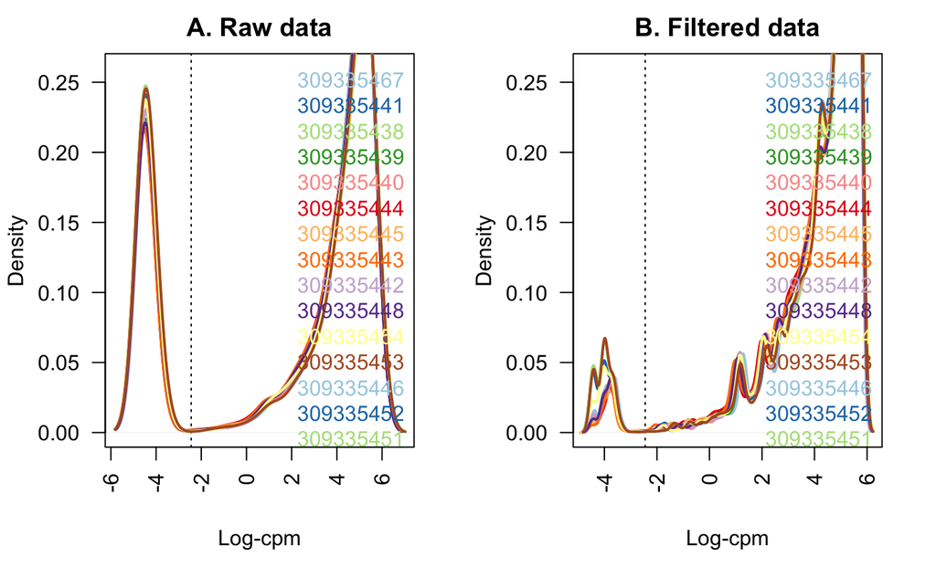

```r
for (i in 2:nsamples){
den <- density(lcpm[,i])
lines(den$x, den$y, col=col[i], lwd=2)
}
legend("topright", colnames(x), text.col=col, bty="n")
```

Unsupervised clustering plot.

```r
par(mfrow=c(1,2))
col.apo <- APOe4
levels(col.apo) <-  brewer.pal(nlevels(col.apo), "Set1")
col.apo <- as.character(col.apo)
col.NR <- NR
levels(col.NR) <-  brewer.pal(nlevels(col.NR), "Set2")
col.NR <- as.character(col.NR)

plotMDS(lcpm, labels=NR, col=col.NR)
title(main="A. nia_reagan")
```

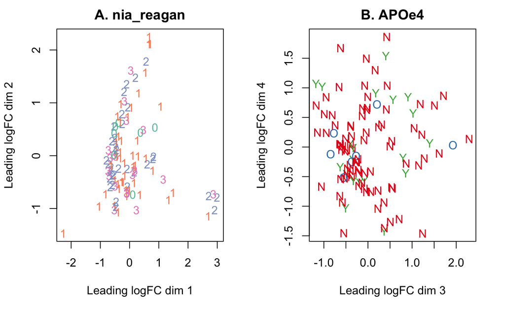

```r
plotMDS(lcpm, labels=APOe4, col=col.apo, dim=c(3,4))
title(main="B. APOe4")
```

The graph on the right shows that the existence of APOe4 allelle can not clearly separate AD patients and healthy individuals. And the graph on the left shows that, using the NIA Reagan criteria, the separation is not acceptable as well.

Use Glimma to generate an interactive plot.

```r
glMDSPlot(lcpm, labels=paste(APOe4, NR, sep="_"),
          groups=x$samples[,c(5,7)], launch=TRUE)
```

Because we can not build meaningful comparison system with the factors we have which have at least 3 levels, we could not go along with the limma library analysis path. So we are going to use general PCA analysis to carry on with our project.

Make a copy of lcpm table and convert it to PCA analysis format.

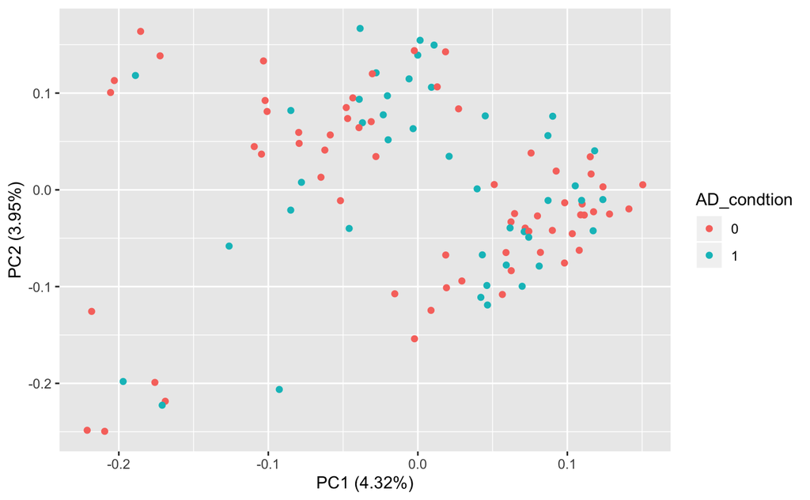

```r
lcpm_table <- cpm(dge, log=TRUE)
lcpm_table <- as.data.frame(t(lcpm_table))
full_table <- lcpm_table
factor_of_interest <- donor_info[,c(4,20)]
full_table$AD_condtion <- as.factor(factor_of_interest$AD_condtion)
autoplot(prcomp(lcpm_table), data=full_table, colour = "AD_condtion")
```

```r
#write.table(lcpm_table, "lcpm_table.txt", sep = ",")
```

The plot above shows that the diagnosis of AD can neither separate the two groups statistically. The analysis part of the project ends here and the rest of it will be trying to accomplish the PCA function in R shiny.